**~/oskar**

# SSH Snoopers Around the World

2022-02-27

I run this website on a cheap machine from my home. It has been live on and off since around April 2021. I use SSH to administrate the machine and have opened the SSH port to the public.

Being able to access the machine from everywhere is extremely convenient, but it also brings some unwanted attention. I tend to get many malicious connections from around the world every day. These are likely performed by some script that tries common usernames and passwords on all open SSH servers with hopes to get access to the server and some valuable information. There are many exposed SSH servers with guessable usernames and passwords, so it is likely not a fruitless pursuit.

In this article I thought I would take a closer look at the login attempts made to my exposed machine. I will redact all IP addresses for privacy purposes.

## Collection

```python
!host=oskar_server ssh $host journalctl --unit sshd --output short-iso > sshd.log
```

Let's have a look at some log entries.

```python
!head -n 5 sshd.log | sed -E 's/[0-9]+\.[0-9]+\.[0-9]+\.[0-9]+/<REDACTED IP>/g'
```

```
2021-04-08T21:10:41+0200 oskar-server sshd[315705]: Invalid user simon from <REDACTED IP> port 39058
2021-04-08T21:10:42+0200 oskar-server sshd[315705]: Received disconnect from <REDACTED IP> port 39058:11: Bye Bye [preauth]
2021-04-08T21:10:42+0200 oskar-server sshd[315705]: Disconnected from invalid user simon <REDACTED IP> port 39058 [preauth]
2021-04-08T21:11:27+0200 oskar-server sshd[315711]: Received disconnect from <REDACTED IP> port 42434:11: Bye Bye [preauth]
2021-04-08T21:11:27+0200 oskar-server sshd[315711]: Disconnected from authenticating user root <REDACTED IP> port 42434 [preauth]
```

The first line above shows what a failed attempt looks like. Someone tried signing in as the user simon on port 39058. We can collect all log entries for failed attempts with a regular expression.

```python
import datetime as dt
import re

ssh = []

with open("sshd.log") as f:
    for line in f:
        match = re.match(r"^(?P<datetime>\S+) (?P<hostname>\S+) sshd\[\d+\]: Invalid user (?P<user>\S+) from (?P<addr>\S+) port (?P<port>\d+)$", line)
        if match is not None:
            groups = match.groupdict()
            groups["datetime"] = dt.datetime.strptime(groups["datetime"], "%Y-%m-%dT%H:%M:%S%z")
            ssh.append(groups)
```

Let's store the attempts in a dataframe for convenience.

```python
import pandas as pd

df_ssh = pd.DataFrame(ssh)
df_ssh.head().replace(r"[0-9]+\.[0-9]+\.[0-9]+\.[0-9]+", "<REDACTED IP>", regex=True)
```

|  | datetime | hostname | user | addr | port |
| --- | --- | --- | --- | --- | --- |
| 0 | 2021-04-08 21:10:41+02:00 | oskar-server | simon | <REDACTED IP> | 39058 |
| 1 | 2021-04-08 21:29:49+02:00 | oskar-server | azman | <REDACTED IP> | 39844 |
| 2 | 2021-04-08 21:32:33+02:00 | oskar-server | carl | <REDACTED IP> | 48146 |
| 3 | 2021-04-08 21:45:10+02:00 | oskar-server | admin | <REDACTED IP> | 55654 |
| 4 | 2021-04-08 21:45:22+02:00 | oskar-server | support | <REDACTED IP> | 59528 |

## Analysis

Now we can have analyse the login attempts. Let's start with the most common usernames.

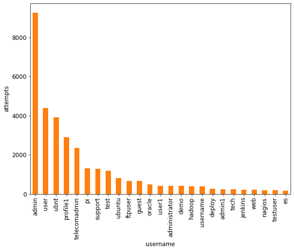

```python
import matplotlib as mpl
mpl.rcParams.update({"figure.figsize": (9.6, 7.2), "font.size": 12})

df_ssh.user.value_counts()[:25].plot.bar(xlabel="username", ylabel="attempts", color="tab:orange")
```

Among the more common usernames are admin (which I assume many people name their superuser), ubnt (apparently the default username for some hardware of an internet service provider named [UniFi](https://ui.com/wi-fi)) and pi (the default username on the [Raspbian](http://www.raspbian.org/) operating system).

Given that you have someone's IP address, you can also get a rough estimate of where they are. One database of IPs and their locations is [GeoIP2](https://www.maxmind.com/en/geoip2-databases), which has a nice Python API. Let's see from where the SSH login attempts are made.

```python
from geoip import geolite2

ips = []

for ip in df_ssh.addr.unique():
    match = geolite2.lookup(ip)
    if match is not None:
        ips.append(match.to_dict())

df_ip = pd.DataFrame(ips)
df_ip.head()
```

|  | ip | country | continent | subdivisions | timezone | location |
| --- | --- | --- | --- | --- | --- | --- |
| 0 | 51.79.164.156 | GB | EU | () | Europe/London | (51.5, -0.13) |
| 1 | 124.193.83.246 | CN | AS | (11) | Asia/Shanghai | (39.9289, 116.3883) |
| 2 | 171.251.19.3 | VN | AS | (64) | Asia/Ho_Chi_Minh | (21.0333, 105.85) |
| 3 | 116.110.55.43 | VN | AS | (64) | Asia/Ho_Chi_Minh | (21.0333, 105.85) |
| 4 | 171.227.215.80 | VN | AS | (64) | Asia/Ho_Chi_Minh | (21.0333, 105.85) |

Among other things, the GeoIP2 database includes country, continent, and coordinates of the IP addresses. Which countries are responsible for the most attempts?

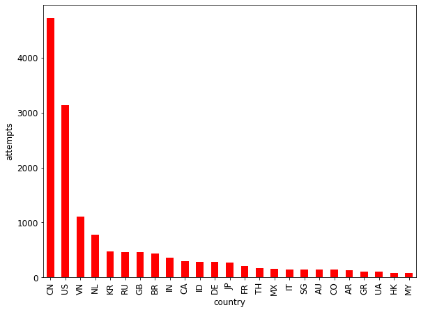

```python
df_ip.country.value_counts()[:25].plot.bar(xlabel="country", ylabel="attempts", color="red")
```

Apparently most attempts are from China, the United States, and Vietnam. Of course some people may also be hiding behind a VPN.

The GeoIP database also includes coordinates of the IP addresses which means that we can draw a heatmap of exact locations. [Matplotlib Basemap Toolkit](https://matplotlib.org/basemap/index.html) has a nice API for plotting 2D data on maps.

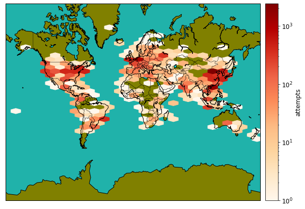

```python
from mpl_toolkits.basemap import Basemap

earth = Basemap(projection="merc", llcrnrlat=-80, urcrnrlat=80, llcrnrlon=-180, urcrnrlon=180, lat_ts=20, resolution="c")
earth.drawcoastlines()
earth.fillcontinents(color="olive", lake_color="aqua")
earth.drawmapboundary(fill_color="lightseagreen")
earth.drawcountries()

df_coords = pd.DataFrame(df_ip.location.tolist(), columns=["lon", "lat"]).dropna()
x, y = earth(df_coords.lat, df_coords.lon)

earth.hexbin(x, y, gridsize=25, bins="log", cmap="OrRd", mincnt=1)
earth.colorbar(label="attempts")
```

Let's plot an orthographic projection centered on Sweden, my home country, as well.

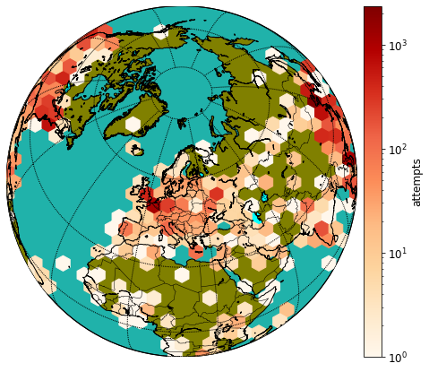

```python
import numpy as np

swe = Basemap(projection="ortho", lat_0=59.334591, lon_0=18.063240, resolution="l")

swe.drawcoastlines()
swe.fillcontinents(color="olive", lake_color="aqua")
swe.drawmapboundary(fill_color="lightseagreen")
swe.drawcountries()
swe.drawmeridians(np.arange(0,360,30))
swe.drawparallels(np.arange(-90,90,30))

x, y = swe(df_coords.lat, df_coords.lon)

swe.hexbin(x, y, gridsize=25, bins="log", cmap="OrRd", mincnt=1)
swe.colorbar(label="attempts")
```

Pretty!

## Protection

To protect your SSH server from simple attacks, you should probably:

- Use public key authentication.
- Set up two factor authentication.
- Use some jail like fail2ban to block IP addresses that fail authentication too many times.
- Disallow root login.

[This page](https://infosec.mozilla.org/guidelines/openssh) has some useful tips.